# DATA 607: Project 1: Regular Expressions

Tom Detzel

2/23/2017

### Introduction

This project calls for parsing a raw text file composed of chess tournament scores. Specs call or retrieving each player’s name, state, total points and pre-tournament rating, then calculating the average pre-tournament rating for each player’s opponents. The refined data are to be exported in a .csv file for use elsewhere.

### 1. Setup and Data

Here is the list of packages followed by a peek at the original fixed-width text file.

```r
library(knitr)
library(stringr)
library(ggplot2)
library(ggthemes)
library(scales)
library(pander)
 panderOptions("digits", 0)
 panderOptions("table.style", "rmarkdown")
 panderOptions("table.alignment.default", "left")
```

#### 1.1 The raw data

Each player’s information is organized in tabular fashion and split across multiple lines. Our strategy is to split the data vertically into two parts by creating an index, then parsing each portion to get the information we need.

```r
input <- readLines("tournamentinfo.txt")
head(input, 12)
```

```
##  [1] "-----------------------------------------------------------------------------------------"
##  [2] " Pair | Player Name                     |Total|Round|Round|Round|Round|Round|Round|Round|"
##  [3] " Num  | USCF ID / Rtg (Pre->Post)       | Pts |  1  |  2  |  3  |  4  |  5  |  6  |  7  |"
##  [4] "-----------------------------------------------------------------------------------------"
##  [5] "    1 | GARY HUA                        |6.0  |W  39|W  21|W  18|W  14|W   7|D  12|D   4|"
##  [6] "   ON | 15445895 / R: 1794   ->1817     |N:2  |W    |B    |W    |B    |W    |B    |W    |"
##  [7] "-----------------------------------------------------------------------------------------"
##  [8] "    2 | DAKSHESH DARURI                 |6.0  |W  63|W  58|L   4|W  17|W  16|W  20|W   7|"
##  [9] "   MI | 14598900 / R: 1553   ->1663     |N:2  |B    |W    |B    |W    |B    |W    |B    |"
## [10] "-----------------------------------------------------------------------------------------"
## [11] "    3 | ADITYA BAJAJ                    |6.0  |L   8|W  61|W  25|W  21|W  11|W  13|W  12|"
## [12] "   MI | 14959604 / R: 1384   ->1640     |N:2  |W    |B    |W    |B    |W    |B    |W    |"
```

```r
# create an index to separate the first and second player lines
idx.player <- seq.int(5, 196, by = 3 )
idx.state <- seq.int(6, 195, by = 3)

# separate the two parts
player <- input[idx.player]
states <- input[idx.state]
```

### 2. Regular expressions

We’ve created two text objects, “player” and “states”, each containing some of the data we want. This a job for regular expressions and **str_extract_all()**. We put what we want into temporary storage so we can reunite it later in an R dataframe. It took some fiddling to get the proper regular expression for capturing the names.

```r
# get the player and opponent IDs from the player object
id <- "(\\d{1,2}\\.?\\d*)"
ids <- str_extract_all(player, id)

# get the names from player
name <- "([:alpha:]{2,})(([:blank:][[:alpha:]-?]{1,})?)+"
names <- str_extract_all(player, name)

# get the pre-rating from states
prerate <- ":\\s+\\d{3,4}"
rates <- str_extract_all(states, prerate)
rates <- str_extract_all(rates, "\\d+")

# get the state names from state
state <- "^\\s+[:alpha:]{2}"
state.names  <- str_trim(str_extract_all(states, state))
```

#### 2.1 Extracted data

Here’s a peek at the extracted material.

- GARY HUA
- DAKSHESH DARURI
- ADITYA BAJAJ
- PATRICK H SCHILLING
- 1794
- 1553
- 1384
- 1716
- *1*, *6.0*, *39*, *21*, *18*, *14*, *7*, *12* and *4*
- *2*, *6.0*, *63*, *58*, *4*, *17*, *16*, *20* and *7*
- *3*, *6.0*, *8*, *61*, *25*, *21*, *11*, *13* and *12*
- *4*, *5.5*, *23*, *28*, *2*, *26*, *5*, *19* and *1*

*ON*, *MI*, *MI* and *MI*

### 3. Combine our results

We can now put the filtered material into an R dataframe for export and to compute the average opponent ratings. This step also involves transforming data types. Some players recorded fewer than seven games, so we have to fill NA in those columns.

```r
# first the simple lists
chessdb <- data.frame(cbind(names, state.names, rates))
chessdb$state.names <- as.factor(unlist(chessdb$state.names))
chessdb$names <- as.factor(unlist(chessdb$names))
chessdb$rates <- as.numeric(unlist(chessdb$rates))

# include NA values; StackOverflow helped with some of this code
n.obs <- sapply(ids, length)
seq.max <- seq_len(max(n.obs))
id.vars <- as.data.frame(t(sapply(ids, "[", i = seq.max)), stringsAsFactors=F)
id.vars[, c(1:9)] <- lapply(id.vars[, c(1:9)], as.numeric)

# put them together, deleting an unneeded ID column
chessdb2 <- cbind(chessdb, id.vars[, -1])
colnames(chessdb2)[1:4] <- c("Name", "State", "Pre.Rating", "Total.Pts")
```

#### 3.1 Extracted data

```
##                  Name State Pre.Rating Total.Pts V3 V4 V5 V6 V7 V8 V9
## 1            GARY HUA    ON       1794       6.0 39 21 18 14  7 12  4
## 2     DAKSHESH DARURI    MI       1553       6.0 63 58  4 17 16 20  7
## 3        ADITYA BAJAJ    MI       1384       6.0  8 61 25 21 11 13 12
## 4 PATRICK H SCHILLING    MI       1716       5.5 23 28  2 26  5 19  1
```

### 4. Compute Opponents’ Mean Rating

This step required writing a bespoke function to look up the pre-match rating for each contestant’s opponents, then calculate their average rating. The apply family of functions didn’t seem to work no matter what I tried.

```r
get.score2 <- function(db){
  # computes the average score for a contestant's opponent
  #
  # Args:
  #   db: a dataframe, in this case our bespoke df dervied from tournamentinfo.txt
  #
  # Note: Not applicable generally; this is crafted just for this purpose
  # Returns: A vector of average scores

              list <- NULL
              for (i in 1:nrow(db)){
                num <- 0
                denom <- 0
                for (j in 5:11){
                  opponent <- as.numeric(db[i,j])
                  if (is.na(opponent)){             # exits the loop on NA value
                    next
                  } else {}
                  rating <- db[opponent, 3]
                  num <- num + rating
                  denom <- denom + 1
                  }
                avg <- round(num/denom, 0)
                list <- append(list, avg)
                }
              return(list)
              }

# append the result to our working data frame
chessdb2$Opp.Avg <- get.score2(chessdb2)
```

#### 4.1 The filtered data

The data is ready for export to csv.

```
##                  Name State Pre.Rating Total.Pts Opp.Avg
## 1            GARY HUA    ON       1794       6.0    1605
## 2     DAKSHESH DARURI    MI       1553       6.0    1469
## 3        ADITYA BAJAJ    MI       1384       6.0    1564
## 4 PATRICK H SCHILLING    MI       1716       5.5    1574
## 5          HANSHI ZUO    MI       1655       5.5    1501
## 6         HANSEN SONG    OH       1686       5.0    1519
```

### 5. Export to .csv

The most trivial step in the process.

```r
# export our csv file
write.csv(chessdb2, "chess.csv")
list.files()[1]
```

```
## [1] "chess.csv"
```

### 6. Scatterplot of scores

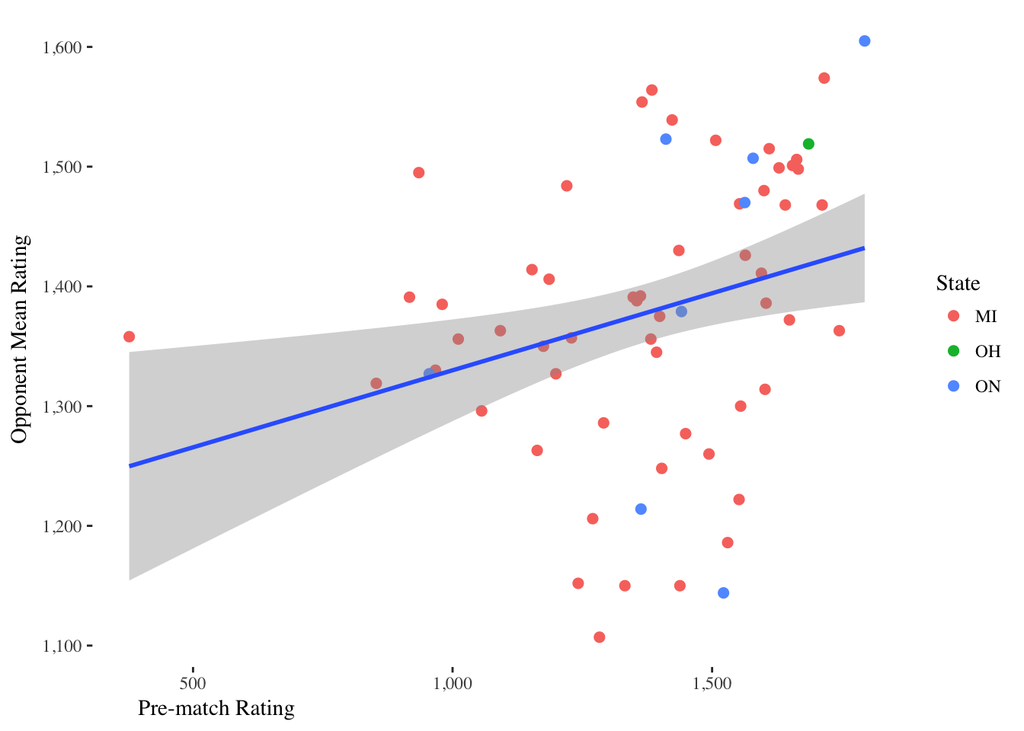

```r
# for fun, try a plot

mytufte <- theme_set(theme_tufte())
mytufte <- theme_update(axis.title.x = element_text(hjust=0.07),
                        axis.title.y = element_text())

ggplot(chessdb2, aes(x=Pre.Rating, y=Opp.Avg)) +
  geom_point(aes(color=State), size=2) +
  scale_y_continuous(labels = scales::comma) +
  scale_x_continuous(labels = scales::comma) +
  geom_smooth(method='lm', level=.90) +
  xlab("Pre-match Rating") + ylab("Opponent Mean Rating") +
  theme_set(mytufte)
```

### Notes

This [regular expression guide](http://gastonsanchez.com/Handling_and_Processing_Strings_in_R.pdf) by Gaston Sanchez was very instructive.

So was [RegExr.com](http://regexr.com/).

And this [post on StackOverflow](http://stackoverflow.com/questions/15201305/how-to-convert-a-list-consisting-of-vector-of-different-lengths-to-a-usable-data).

Finally, [Google’s R style guide](https://google.github.io/styleguide/Rguide.xml#functiondocumentation).